# MATH-256 - Exam #2 (Fall 2021)

These questions are intended to help you practice for Exam #2. The real exam will feature 2-3 questions that follow a similar format. All course content up until this point may appear on the exam, though the primary focus will be on Chapters 3, 4, and 5.1 of the textbook, the probability, random variables, and central limit theorem lecture slides, and Labs 3 and 4.

You should record your answers in an R Markdown document, submitting the compiled HTML output.

$~$

### Question #1

The Behavioral Risk Factor Surveillance System (BRFSS) is an annual telephone survey designed to identify risk factors in the adult population and track emerging health tends. Two questions the survey asked respondents were “Do you have health care coverage?” (table rows) and “How would you rate your current health?” (table columns). The table below summarizes responses to these questions:

|  | Excellent | Very_Good | Good | Fair | Poor | Total |
| --- | --- | --- | --- | --- | --- | --- |
| No, not covered | 459 | 727 | 854 | 385 | 99 | 2524 |
| Yes, covered | 4198 | 6245 | 4821 | 1634 | 578 | 17476 |
| Total | 4657 | 6972 | 5675 | 2019 | 677 | 20000 |

**1-A**: If a single individual is drawn at random from the population represented by these respondents, estimate the probability that they have excellent health *or* they have health care coverage.

$~$

**1-B**: Consider a random sample of $n = 10$ individuals drawn from the population represented by these respondents (you may assume the population is large, so each draw is independent). Letting the random variable $X$ represent the number of individuals with health care coverage in this sample, provide a *probability model* for $X$ (be sure to specify numeric values for the model’s parameters).

$~$

**1-C**: Using the probability model you described in 1-B, find the probability that *at least* 7 individuals in a random sample of $n = 10$ have health care coverage.

$~$

**1-D**: Using the probability model you described in 1-B, find the probability that *exactly* 9 individuals in a random sample of $n = 10$ have health care coverage.

$~$

### Question #2

Historical data indicates the average daily high temperature in Los Angeles, CA in July is 77 degrees Fahrenheit, with a standard deviation of 5 degrees. It is reasonable to assume these daily temperatures follow a Normal distribution. Further, the following equation describes how to convert degrees Fahrenheit (F) to Celsius (C):

$$C = (F - 32)*\tfrac{5}{9}$$
$~$

**2-A**: Letting the random $X$ denote the high temperature *in Fahrenheit* of a randomly chosen July day in Los Angeles, provide a probability model for $X$ (be sure to specify numeric values for the model’s parameters).

$~$

**2-B**: Letting the random $Y$ denote the high temperature *in Celsius* of a randomly chosen July day in Los Angeles, provide a probability model for $Y$ (be sure to specify numeric values for the model’s parameters). **Hint**: Adding a *constant* to random variable shift the expected value of that random variable by a fixed amount (ie: $E(X + c) = E(X) + c$), but it will have no impact on the variance or standard deviation (ie: $Var(X + c) = Var(X)$).

$~$

**2-C**: Using the probability models in 2-A and 2-B, determine which is more likely: a random July day being *warmer* than 83 degrees Fahrenheit, or a random July day being *colder* than 23 degrees Celsius.

$~$

**2-D**: Using the probability model from 2-B, estimate the interquartile range (IQR) of July temperatures in Los Angeles (in Celsius).

$~$

### Question #3

The Colleges 2019 dataset contains variables describing higher education institutions that primarily bachelors degrees and enroll at least 400 students. It was obtained from The College Scorecard, a comprehensive government database. For each institution, it includes enrollment and admissions variables, student demographics, costs and faculty salaries, as well as student outcomes such as median debt upon graduation and median 10-year salary

```r
colleges <- read.csv("https://remiller1450.github.io/data/Colleges2019.csv")
```

**3-A**: Construct a Q-Q plot of the variable “Debt_median” in the full dataset. Based upon this plot, does this variable appear to be Normally distributed?

$~$

**3-B**: The pairs of histograms and Q-Q plots depicted below describe three different scenarios:

1. The distribution of a population of size $N = 200$
2. The distribution of sample means across 200 different random samples of size $n = 10$ from the population referenced in *i*
3. The distribution of sample means across 200 different random samples of size $n = 40$ from the population referenced in *i*

For this question, match each set of plots (ie: those for variable “x”, “y”, or “z”) with the corresponding scenario (ie: *i*, *ii*, or *iii*). Provide a brief justification for your choices (no use of R is required for this question).

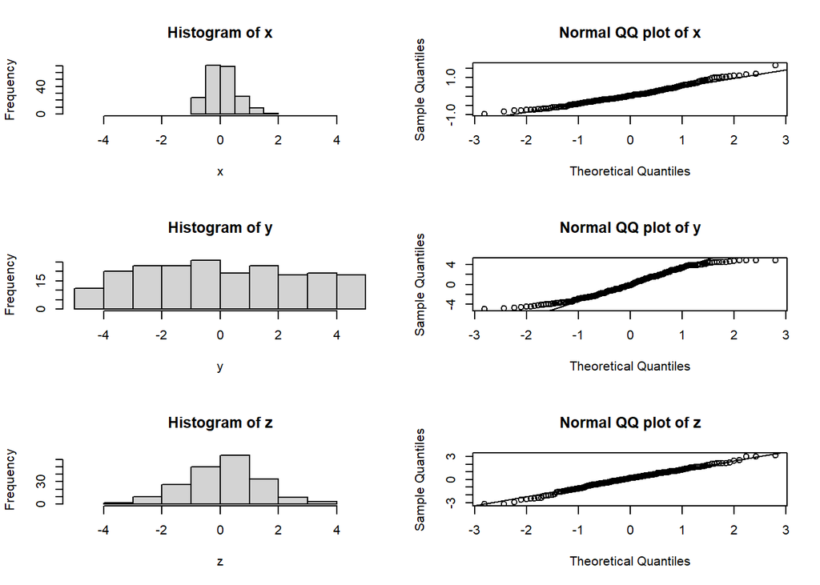